# End to End Machine Learning Cheat Sheet

> for every single Problem use the following startegy with your own modifications.

## Steps :- [ Decomposition ]

1. Specify The Goal of Your Project / Model and Highlight it
2. Load The Data into a Pandas Frame
   1. CSV File
   2. Excel File
3. Perform Data Exploratory Analysis
   1. Pandas Routine.
   2. SeaBorn/Matplotlib Routine.
   3. Insights Noted Down.
4. Data Preprocessing for Machine Learning
   1. Heat Map.
   2. Drop Un-Necessary Columns.
   3. Handling Categorical Data.
   4. Normalization.
   5. Standard Scaler.
   6. Perform PCA
5. Training Process
   - For Classification Problem
     1. Logistic Regression.
     2. Decision Tree Classifer.
     3. K Nearest Neighbour.
     4. Support Vector Classifer With Grid Search.
     5. Random Forest Classifer With Grid Search.
     6. XGBoost Classifer With Grid Search.
     7. Voting and Selecting Best .
   - For Regression Problem
     1. Linear Regression.
     2. Polynomial Regressor.
     3. Lasso Regressor.
     4. Ridge Regressor.
     5. Decision Tree Regressor.
     6. Support Vector Regressor With Grid Search.
     7. Random Forest Regressor With Grid Search.
     8. XGBoost Regressor With Grid Search.
   - For Clustering Problem
     1. K-Means.
     2. Heirarichal Clustering.
     3. PCA.
6. Model Evaluation
   - For Classification Problem
     - Confusion Matrix.
   - For Regression Problem
     - Error Measurement.
       - Mean Squared Error.
       - Mean Absolute Error.
       - Root Mean Squared Error.
       - Mean Absolute Percentage Error.
     - Score Measurement
       - R Square Score.
7. Visualization Stage
   - Visualize Whatever you can show to your Client.
     - Seaborn / Matplotlib.
8. Inference Stage
   - Make your Work Robust.
   - Saving and Loading Part.

### References you might need

- Visualizers
  - Seaborn [link to Seaborn!](https://seaborn.pydata.org/)
  - Py Gal Cheatsheet [link to Pygal Cheatshee!](https://www.kaggle.com/raenish/cheatsheet-40-pygal-interactive-plots)
  - Bokeh [link to Bokeh!](https://docs.bokeh.org/en/latest/docs/gallery.html#gallery)
  - Plotly [link to plotly!](https://plotly.com/python/)

## All Packages you need for this

```python
# Core
import numpy as np
import pandas as pd
import matplotlib.pyplot as plt
import seaborn as sns; sns.set()
import sklearn
import xlrd

# Pre Processing
from sklearn.model_selection import train_test_split
from sklearn.preprocessing import StandardScaler
from sklearn.preprocessing import MinMaxScaler
from sklearn.decomposition import PCA

# Error Metrics
from sklearn.metrics import mean_absolute_error
from sklearn.metrics import mean_squared_error
from sklearn.metrics import r2_score

# Regressors
from sklearn.ensemble import GradientBoostingRegressor
from sklearn.ensemble import RandomForestRegressor
from sklearn.linear_model import LinearRegression
from sklearn.ensemble import VotingRegressor

# Classifiers
from sklearn.linear_model import LogisticRegression
from sklearn.svm import SVC, LinearSVC
from sklearn.ensemble import RandomForestClassifier
from sklearn.neighbors import KNeighborsClassifier
from sklearn.naive_bayes import GaussianNB
from sklearn.linear_model import Perceptron
from sklearn.linear_model import SGDClassifier
from sklearn.tree import DecisionTreeClassifier
from sklearn.ensemble import RandomForestClassifier, GradientBoostingClassifier

#Cross Validation
from sklearn.model_selection import GridSearchCV
```

## 1. Specify The Goal of Your Project / Model and Highlight it

> (e.g. : Predict Number of Eggs That a New Customer would eat per day )

### Learn how to use [Mark Down](https://www.markdowntutorial.com/) Techniques to use it for collecting your insights and make your notebook pretty!

## 2. Load The Data into a Pandas Frame

```python
# For CSV File
df=pd.read_csv('train.csv')
```

# 3. Perform Data Exploratory Analysis

## Pandas Routine

#### [Pandas Cheat Sheet](https://pandas.pydata.org/Pandas_Cheat_Sheet.pdf) for Data Wrangling

```python
df
```

|  | PassengerId | Survived | Pclass | Name | Sex | Age | SibSp | Parch | Ticket | Fare | Cabin | Embarked |
| --- | --- | --- | --- | --- | --- | --- | --- | --- | --- | --- | --- | --- |
| 0 | 1 | 0 | 3 | Braund, Mr. Owen Harris | male | 22.0 | 1 | 0 | A/5 21171 | 7.2500 | NaN | S |
| 1 | 2 | 1 | 1 | Cumings, Mrs. John Bradley (Florence Briggs Th... | female | 38.0 | 1 | 0 | PC 17599 | 71.2833 | C85 | C |
| 2 | 3 | 1 | 3 | Heikkinen, Miss. Laina | female | 26.0 | 0 | 0 | STON/O2. 3101282 | 7.9250 | NaN | S |
| 3 | 4 | 1 | 1 | Futrelle, Mrs. Jacques Heath (Lily May Peel) | female | 35.0 | 1 | 0 | 113803 | 53.1000 | C123 | S |
| 4 | 5 | 0 | 3 | Allen, Mr. William Henry | male | 35.0 | 0 | 0 | 373450 | 8.0500 | NaN | S |
| ... | ... | ... | ... | ... | ... | ... | ... | ... | ... | ... | ... | ... |
| 886 | 887 | 0 | 2 | Montvila, Rev. Juozas | male | 27.0 | 0 | 0 | 211536 | 13.0000 | NaN | S |
| 887 | 888 | 1 | 1 | Graham, Miss. Margaret Edith | female | 19.0 | 0 | 0 | 112053 | 30.0000 | B42 | S |
| 888 | 889 | 0 | 3 | Johnston, Miss. Catherine Helen "Carrie" | female | NaN | 1 | 2 | W./C. 6607 | 23.4500 | NaN | S |
| 889 | 890 | 1 | 1 | Behr, Mr. Karl Howell | male | 26.0 | 0 | 0 | 111369 | 30.0000 | C148 | C |
| 890 | 891 | 0 | 3 | Dooley, Mr. Patrick | male | 32.0 | 0 | 0 | 370376 | 7.7500 | NaN | Q |

891 rows × 12 columns

#### Drop Specific Columns

```python
df=df.drop(['PassengerId','Name','Ticket','Cabin'], 1)
df
```

|  | Survived | Pclass | Sex | Age | SibSp | Parch | Fare | Embarked |
| --- | --- | --- | --- | --- | --- | --- | --- | --- |
| 0 | 0 | 3 | male | 22.0 | 1 | 0 | 7.2500 | S |
| 1 | 1 | 1 | female | 38.0 | 1 | 0 | 71.2833 | C |
| 2 | 1 | 3 | female | 26.0 | 0 | 0 | 7.9250 | S |
| 3 | 1 | 1 | female | 35.0 | 1 | 0 | 53.1000 | S |
| 4 | 0 | 3 | male | 35.0 | 0 | 0 | 8.0500 | S |
| ... | ... | ... | ... | ... | ... | ... | ... | ... |
| 886 | 0 | 2 | male | 27.0 | 0 | 0 | 13.0000 | S |
| 887 | 1 | 1 | female | 19.0 | 0 | 0 | 30.0000 | S |
| 888 | 0 | 3 | female | NaN | 1 | 2 | 23.4500 | S |
| 889 | 1 | 1 | male | 26.0 | 0 | 0 | 30.0000 | C |
| 890 | 0 | 3 | male | 32.0 | 0 | 0 | 7.7500 | Q |

891 rows × 8 columns

### Check For Missing Data

```python
print(df.isnull().sum().sort_values(ascending=False))
```

```
Age         177
Embarked      2
Fare          0
Parch         0
SibSp         0
Sex           0
Pclass        0
Survived      0
dtype: int64
```

### Drop Rows with None Values

```python
df=df.dropna()
df
```

|  | Survived | Pclass | Sex | Age | SibSp | Parch | Fare | Embarked |
| --- | --- | --- | --- | --- | --- | --- | --- | --- |
| 0 | 0 | 3 | male | 22.0 | 1 | 0 | 7.2500 | S |
| 1 | 1 | 1 | female | 38.0 | 1 | 0 | 71.2833 | C |
| 2 | 1 | 3 | female | 26.0 | 0 | 0 | 7.9250 | S |
| 3 | 1 | 1 | female | 35.0 | 1 | 0 | 53.1000 | S |
| 4 | 0 | 3 | male | 35.0 | 0 | 0 | 8.0500 | S |
| ... | ... | ... | ... | ... | ... | ... | ... | ... |
| 885 | 0 | 3 | female | 39.0 | 0 | 5 | 29.1250 | Q |
| 886 | 0 | 2 | male | 27.0 | 0 | 0 | 13.0000 | S |
| 887 | 1 | 1 | female | 19.0 | 0 | 0 | 30.0000 | S |
| 889 | 1 | 1 | male | 26.0 | 0 | 0 | 30.0000 | C |
| 890 | 0 | 3 | male | 32.0 | 0 | 0 | 7.7500 | Q |

712 rows × 8 columns

### Correct Index

```python
df=df.reset_index(drop=True)
df
```

|  | Survived | Pclass | Sex | Age | SibSp | Parch | Fare | Embarked |
| --- | --- | --- | --- | --- | --- | --- | --- | --- |
| 0 | 0 | 3 | male | 22.0 | 1 | 0 | 7.2500 | S |
| 1 | 1 | 1 | female | 38.0 | 1 | 0 | 71.2833 | C |
| 2 | 1 | 3 | female | 26.0 | 0 | 0 | 7.9250 | S |
| 3 | 1 | 1 | female | 35.0 | 1 | 0 | 53.1000 | S |
| 4 | 0 | 3 | male | 35.0 | 0 | 0 | 8.0500 | S |
| ... | ... | ... | ... | ... | ... | ... | ... | ... |
| 707 | 0 | 3 | female | 39.0 | 0 | 5 | 29.1250 | Q |
| 708 | 0 | 2 | male | 27.0 | 0 | 0 | 13.0000 | S |
| 709 | 1 | 1 | female | 19.0 | 0 | 0 | 30.0000 | S |
| 710 | 1 | 1 | male | 26.0 | 0 | 0 | 30.0000 | C |
| 711 | 0 | 3 | male | 32.0 | 0 | 0 | 7.7500 | Q |

712 rows × 8 columns

### Describe Your Data

```python
df.describe()
```

|  | Survived | Pclass | Age | SibSp | Parch | Fare |
| --- | --- | --- | --- | --- | --- | --- |
| count | 712.000000 | 712.000000 | 712.000000 | 712.000000 | 712.000000 | 712.000000 |
| mean | 0.404494 | 2.240169 | 29.642093 | 0.514045 | 0.432584 | 34.567251 |
| std | 0.491139 | 0.836854 | 14.492933 | 0.930692 | 0.854181 | 52.938648 |
| min | 0.000000 | 1.000000 | 0.420000 | 0.000000 | 0.000000 | 0.000000 |
| 25% | 0.000000 | 1.000000 | 20.000000 | 0.000000 | 0.000000 | 8.050000 |
| 50% | 0.000000 | 2.000000 | 28.000000 | 0.000000 | 0.000000 | 15.645850 |
| 75% | 1.000000 | 3.000000 | 38.000000 | 1.000000 | 1.000000 | 33.000000 |
| max | 1.000000 | 3.000000 | 80.000000 | 5.000000 | 6.000000 | 512.329200 |

> Have a look with your Eyes on the Maximum and Minimum of Each column -->> survived , Pclass , Parch

## Seaborn Routine

### Heat Map

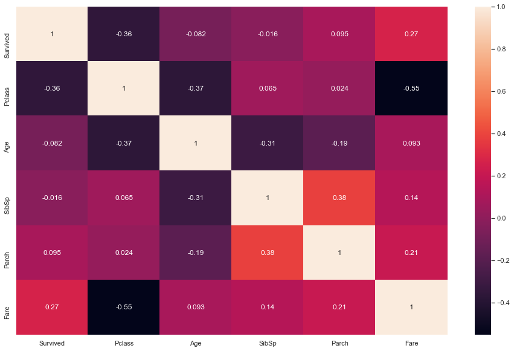

```python
plt.figure(figsize = (16,10))
sns_plot=sns.heatmap(df.corr(),annot= True)
plt.show()
# Saving
sns_plot.figure.savefig("Heat Map.png")
```

> Look at Survived Column as its the label we can see that parch and Sib SP are very low correlated with our label

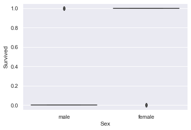

```python
sns_plot = sns.boxplot(x='Sex', y='Survived', data=df)
#sns_plot.figure.savefig("Work Ethics with Total Hours")
```

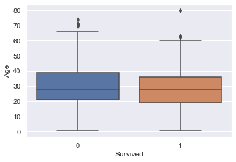

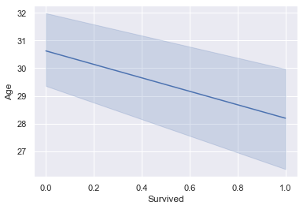

```python
plot = sns.boxplot(x='Survived', y='Age', data=df)
plt.show()
_ = sns.lineplot(x='Survived', y='Age', data=df)
```

# 4. Data Preprocessing

#### Categorical Data Handling

```python
df=pd.get_dummies(df)
df
```

|  | Survived | Pclass | Age | SibSp | Parch | Fare | Sex_female | Sex_male | Embarked_C | Embarked_Q | Embarked_S |
| --- | --- | --- | --- | --- | --- | --- | --- | --- | --- | --- | --- |
| 0 | 0 | 3 | 22.0 | 1 | 0 | 7.2500 | 0 | 1 | 0 | 0 | 1 |
| 1 | 1 | 1 | 38.0 | 1 | 0 | 71.2833 | 1 | 0 | 1 | 0 | 0 |
| 2 | 1 | 3 | 26.0 | 0 | 0 | 7.9250 | 1 | 0 | 0 | 0 | 1 |
| 3 | 1 | 1 | 35.0 | 1 | 0 | 53.1000 | 1 | 0 | 0 | 0 | 1 |
| 4 | 0 | 3 | 35.0 | 0 | 0 | 8.0500 | 0 | 1 | 0 | 0 | 1 |
| ... | ... | ... | ... | ... | ... | ... | ... | ... | ... | ... | ... |
| 707 | 0 | 3 | 39.0 | 0 | 5 | 29.1250 | 1 | 0 | 0 | 1 | 0 |
| 708 | 0 | 2 | 27.0 | 0 | 0 | 13.0000 | 0 | 1 | 0 | 0 | 1 |
| 709 | 1 | 1 | 19.0 | 0 | 0 | 30.0000 | 1 | 0 | 0 | 0 | 1 |
| 710 | 1 | 1 | 26.0 | 0 | 0 | 30.0000 | 0 | 1 | 1 | 0 | 0 |
| 711 | 0 | 3 | 32.0 | 0 | 0 | 7.7500 | 0 | 1 | 0 | 1 | 0 |

712 rows × 11 columns

## Splitting Data

```python
y=df['Survived']
X=df.drop(['Survived'],1)
```

```python
X_train,X_test,y_train,y_test =train_test_split(X,y , test_size=0.25, random_state=42)
```

## Normalization

```python
data=df.values
data
```

[output not shown]

```python
scaler = MinMaxScaler()
scaler.fit(data)
normalized=scaler.transform(data)
np.min(normalized)
```

[output not shown]

```python
normalized
```

[output not shown]

## Standardization

```python
data
```

```
array([[ 0.,  3., 22., ...,  0.,  0.,  1.],
       [ 1.,  1., 38., ...,  1.,  0.,  0.],
       [ 1.,  3., 26., ...,  0.,  0.,  1.],
       ...,
       [ 1.,  1., 19., ...,  0.,  0.,  1.],
       [ 1.,  1., 26., ...,  1.,  0.,  0.],
       [ 0.,  3., 32., ...,  0.,  1.,  0.]])
```

```python
scaler = StandardScaler()
scaler.fit(data)
standardized=scaler.transform(data)
np.std(standardized)
```

```
1.0
```

## PCA

```python
scaler=MinMaxScaler()
scaler.fit(X_train)
scaled_train=scaler.transform(X_train)
scaled_test=scaler.transform(X_test)
```

```python
scaled_train
```

```
array([[1.        , 0.30887158, 0.        , ..., 0.        , 1.        ,
        0.        ],
       [0.        , 0.58532295, 0.        , ..., 0.        , 0.        ,
        1.        ],
       [1.        , 0.2963056 , 0.        , ..., 1.        , 0.        ,
        0.        ],
       ...,
       [1.        , 0.560191  , 0.        , ..., 0.        , 0.        ,
        1.        ],
       [0.5       , 0.09525006, 0.2       , ..., 0.        , 0.        ,
        1.        ],
       [1.        , 0.24604172, 0.        , ..., 0.        , 0.        ,
        1.        ]])
```

```python
pca = PCA(n_components=2)

pct = pca.fit_transform(scaled_train)
print(pca.explained_variance_)
```

```
[0.48324539 0.29578823]
```

```python
principal_df = pd.DataFrame(pct,columns=['pc1','pc2'])
principal_df=principal_df.reset_index(drop=True)

Label_df=pd.DataFrame(y_train)
Label_df=Label_df.reset_index(drop=True)

finaldf= pd.concat([principal_df,Label_df],axis=1)
```

```python
finaldf
```

|  | pc1 | pc2 | Survived |
| --- | --- | --- | --- |
| 0 | -0.401541 | 0.470844 | 0 |
| 1 | -0.452645 | 0.150556 | 0 |
| 2 | 1.118175 | 0.596766 | 1 |
| 3 | -0.622391 | -0.195983 | 1 |
| 4 | -0.623261 | -0.188260 | 0 |
| ... | ... | ... | ... |
| 529 | -0.597174 | -0.220481 | 0 |
| 530 | -0.156032 | 1.214272 | 0 |
| 531 | -0.626528 | -0.184378 | 1 |
| 532 | -0.512018 | -0.063844 | 1 |
| 533 | -0.618656 | -0.206787 | 0 |

534 rows × 3 columns

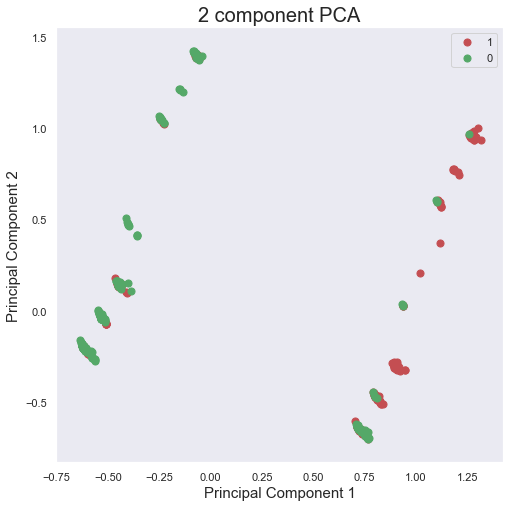

```python
fig = plt.figure(figsize = (8,8))
ax = fig.add_subplot(1,1,1)
ax.set_xlabel('Principal Component 1', fontsize = 15)
ax.set_ylabel('Principal Component 2', fontsize = 15)
ax.set_title('2 component PCA', fontsize = 20)
targets = [1,0]
colors = ['r', 'g']
for target, color in zip(targets,colors):
    indicesToKeep = finaldf['Survived'] == target
    ax.scatter(finaldf.loc[indicesToKeep, 'pc1']
               , finaldf.loc[indicesToKeep, 'pc2']
               , c = color
               , s = 50)
ax.legend(targets)
ax.grid()
```

# 5. Training Process

## Classifiers

```python
import warnings
warnings.filterwarnings("ignore")
```

```python
from sklearn.linear_model import LogisticRegression


def set_grid(est, param, cv = 20):
    cv = GridSearchCV(
        estimator = est,
        param_grid = param,
        cv = cv,
        scoring = "accuracy",
        verbose = 0
    )
    return cv

def print_results(model_cv, X_test_s, y_test):
    return (model_cv.best_score_, model_cv.best_params_, model_cv.score(X_test_s, y_test))
```

```python
lg = LogisticRegression()
param_cv = {"C": [0.001, 0.005, 0.01, 0.1, 1, 5]}

lg_cv = set_grid(lg, param_cv)
lg_cv.fit(X_train, y_train)
```

```
GridSearchCV(cv=20, error_score=nan,
             estimator=LogisticRegression(C=1.0, class_weight=None, dual=False,
                                          fit_intercept=True,
                                          intercept_scaling=1, l1_ratio=None,
                                          max_iter=100, multi_class='auto',
                                          n_jobs=None, penalty='l2',
                                          random_state=None, solver='lbfgs',
                                          tol=0.0001, verbose=0,
                                          warm_start=False),
             iid='deprecated', n_jobs=None,
             param_grid={'C': [0.001, 0.005, 0.01, 0.1, 1, 5]},
             pre_dispatch='2*n_jobs', refit=True, return_train_score=False,
             scoring='accuracy', verbose=0)
```

```python
print_results(lg_cv, X_test, y_test)
```

```
(0.7975783475783477, {'C': 5}, 0.7752808988764045)
```

```python
from sklearn.neighbors import KNeighborsClassifier
```

```python
knn = KNeighborsClassifier()
param_cv = {"n_neighbors" : range(1, 25)}

knn_cv = set_grid(knn, param_cv)
knn_cv.fit(X_train, y_train)
```

```
GridSearchCV(cv=20, error_score=nan,
             estimator=KNeighborsClassifier(algorithm='auto', leaf_size=30,
                                            metric='minkowski',
                                            metric_params=None, n_jobs=None,
                                            n_neighbors=5, p=2,
                                            weights='uniform'),
             iid='deprecated', n_jobs=None,
             param_grid={'n_neighbors': range(1, 25)}, pre_dispatch='2*n_jobs',
             refit=True, return_train_score=False, scoring='accuracy',
             verbose=0)
```

```python
print_results(knn_cv, X_test, y_test)
```

```
(0.7233618233618233, {'n_neighbors': 6}, 0.6292134831460674)
```

```python
rf = RandomForestClassifier(n_estimators = 500)
param_cv = {"max_depth" : [5, 7, 10], "min_samples_split" : [30, 40, 45]}
rf_cv = set_grid(rf, param_cv)
rf_cv.fit(X_train, y_train)
```

```
GridSearchCV(cv=20, error_score=nan,
             estimator=RandomForestClassifier(bootstrap=True, ccp_alpha=0.0,
                                              class_weight=None,
                                              criterion='gini', max_depth=None,
                                              max_features='auto',
                                              max_leaf_nodes=None,
                                              max_samples=None,
                                              min_impurity_decrease=0.0,
                                              min_impurity_split=None,
                                              min_samples_leaf=1,
                                              min_samples_split=2,
                                              min_weight_fraction_leaf=0.0,
                                              n_estimators=500, n_jobs=None,
                                              oob_score=False,
                                              random_state=None, verbose=0,
                                              warm_start=False),
             iid='deprecated', n_jobs=None,
             param_grid={'max_depth': [5, 7, 10],
                         'min_samples_split': [30, 40, 45]},
             pre_dispatch='2*n_jobs', refit=True, return_train_score=False,
             scoring='accuracy', verbose=0)
```

```python
print_results(rf_cv, X_test, y_test)
```

```
(0.7994301994301994,
 {'max_depth': 10, 'min_samples_split': 40},
 0.7865168539325843)
```

```python
gb = GradientBoostingClassifier(n_estimators = 700)
param_cv = {"learning_rate" : [0.001, 0.01, 1, 5], "max_depth": [3, 10, 15]}
gb_cv = set_grid(gb, param_cv)
gb_cv.fit(X_train, y_train)
```

[output not shown]

[output cut: 65 more lines]

[output not shown]

```python
print_results(gb_cv, X_test, y_test)
```

[output not shown]

```python
from sklearn.svm import SVC
```

```python
svc_linear = SVC(kernel = "linear")
param_cv = {"C": [0.001, 0.01, 1, 3]}
svc_linear_cv = set_grid(svc_linear, param_cv)
svc_linear_cv.fit(X_train, y_train)
```

[output not shown]

[output cut: 44 more lines]

[output not shown]

```python
print_results(svc_linear_cv, X_test, y_test)
```

[output not shown]

```python
svc_rb = SVC(kernel = "rbf")
param_cv = {"C" : [10, 20, 30, 40], "gamma" : [0.1, 0.5, 1, 5, 10]}
svc_rb_cv = set_grid(svc_rb, param_cv)
svc_rb_cv.fit(X_train, y_train)
```

[output not shown]

```python
print_results(svc_rb_cv, X_test, y_test)
```

[output not shown]

```python
from sklearn.ensemble import VotingClassifier

classifiers = [
    ('svc_rbf', SVC(kernel = "rbf", C = 20, gamma = 0.5)),
    ('gb', GradientBoostingClassifier(learning_rate = 0.01, max_depth = 10)),
    ('rv', RandomForestClassifier(n_estimators = 700, max_depth = 7, min_samples_split = 30)),
    ('lg', LogisticRegression())
]

clf = VotingClassifier(classifiers, voting = "hard")
```

```python
clf.fit(X_train, y_train)
clf.score(X_test, y_test)
```

[output not shown]

[output cut: 50 more lines]

[output not shown]

```python
y_pred=clf.predict(X_test)
```

[output not shown]

# 6. Model Evaluation

### Confusion Matrix

[figure not shown]

```python
from sklearn.metrics import plot_confusion_matrix
import matplotlib.pyplot as plt

disp = plot_confusion_matrix(clf, X_test, y_test,
                              display_labels=['Yes','No'],
                              cmap=plt.cm.Blues)
```

```python
Actual
```

|  | Survived |
| --- | --- |
| 506 | 1 |
| 394 | 1 |
| 210 | 0 |
| 247 | 1 |
| 437 | 0 |
| ... | ... |
| 259 | 1 |
| 483 | 1 |
| 456 | 1 |
| 211 | 0 |
| 543 | 0 |

178 rows × 1 columns

## Saving and Loading

```python
import pickle

filename = 'finalized_model.sav'
pickle.dump(model, open(filename, 'wb'))

# save the model
pickle.dump(model, open('model.pkl', 'wb'))
# save the scaler
pickle.dump(scaler, open('scaler.pkl', 'wb'))


loaded_model = pickle.load(open(filename, 'rb'))
result = loaded_model.score(X_test, Y_test)

print(result)
```

[output not shown]

```python
file_name = "xgb_reg.pkl"

# save
pickle.dump(xgb_model, open(file_name, "wb"))

# load
xgb_model_loaded = pickle.load(open(file_name, "rb"))

# test
ind = 1
test = X_val[ind]
xgb_model_loaded.predict(test)[0] == xgb_model.predict(test)[0]
```